# Homework 1 of Statistical Methods in Data Science

Barba Paolo, Candi Matteo

04/12/22

# Exercise 1 Stopping Time

### Process:

Suppose that $X ∼ Unif(0, 1)$, and suppose we independently draw ${Y_{1}, Y_{2}, Y_{3}, \dots}$ from yet another $Unif(0, 1)$ model until we reach the random stopping time T such that $(Y_{T} > X)$. The goal is to understand the distribution of T.

### Simulation study:

#### 1)

The idea is the following: We generate m $Unif(0,1)$ and then use them as parameters of the geometric distributions. $X ∼ Unif(0, 1)$ and the distribution of $Y | X = x$ is a geometric distribution .

We run a simulation with size: M = {100, 1000, 10000, 100000, 1000000, 10000000}

```r
rm(list=ls())
set.seed(13112221)
Sim <- c(100, 1000, 10000, 100000, 1000000, 10000000)  # vector of the size
fin <- c()                # inizialize the the vector of the result
timing_fun <- function(s){
  beg <- Sys.time()       # starting time
  stop_simulations <-  rgeom(n = s, prob = runif(n = s))   # run the simulation
  fin <- Sys.time() - beg #ending time
  return(fin)
}

results <- sapply(Sim , timing_fun)

tab_time <- data.frame (Simulation_size  = c("100", "1000", "10000", "100000", "1000000", "10000000") , Computational_time = results  )   # creating the dataframe of the results
tab_time
```

```
##   Simulation_size Computational_time
## 1             100       9.417534e-05
## 2            1000       1.299381e-04
## 3           10000       1.114845e-03
## 4          100000       1.143599e-02
## 5         1000000       1.128209e-01
## 6        10000000       1.188160e+00
```

```r
paste("The median speed over M is : " , median(results))
```

```
## [1] "The median speed over M is :  0.00627541542053223"
```

#### 2)

Most of the time 10 simulations are enough to detect a y greater than the x ( explanations are shown below) . If 10 simulations are not enough probably the drawn x is big and such that we need to draw more Y.

[Link to exercise one run on Colab](https://colab.research.google.com/drive/14VD1MdfOC8uTaIAH2cPVxBjPZ9vhfgn7?usp=sharing#scrollTo=Z7c1CG7eEkZU).

Let’s start the analysis with a fixed size M equal to 10000.

```r
condition <- function(y_vec , t = 0 , val){
  for (y in y_vec){
    if (y > val){break}
    else t <- t + 1
  }
  return(t)
}


stopping_time <- function(M){
  beg <- Sys.time()
  t_data <- rep(NA , M)
  x <- runif(M)
  for (m in 1:M){
    cond <- condition(runif(10) , val = x[m])
    t <- cond + 1
    if (cond != 0)
      while(cond %% 10 == 0){
        cond <- cond + condition(runif(cond) * 4 , val = x[m])
        t <- t + cond
      }
    t_data[m] <- t
  }
  return(t_data)
}
```

First, we compare the simulation results with the true function:

$$Pr(T = t) = \frac{1}{t(t+1)}$$
for t $∈${1,2,3,…}

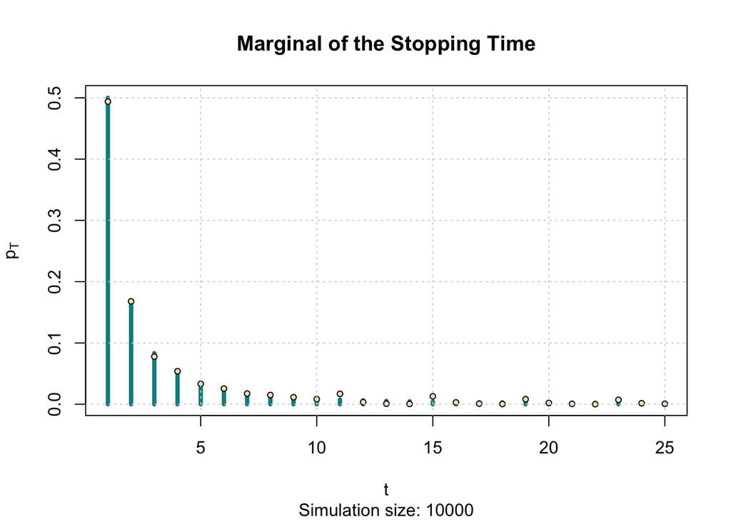

```r
pT <- function(t)  1/(t*(t+1))  # True Distribution
t_seq <- 1:25      #Plot it zooming between t = 1 and t = 25
M <- 10000

stop_time <- stopping_time(M)
p_hat <- proportions(table(stop_time))

# Plot the true distribution
plot(t_seq, pT(t_seq),
     type = "h",
     lwd = 4,
     col = "cyan4",
     ylab = expression(p[T]),
     xlab = "t",
     main = "Marginal of the Stopping Time",
     sub = paste("Simulation size:", M))

# Add the simulation points
points(t_seq, p_hat[t_seq], pch = 21,
       col = "black", bg = "bisque", cex = .7)
grid()
```

Let’s see the series of averages.

```r
step_size <- 10    #set a step size
ave_step  <- seq(1, length(stop_time), step_size)  #start the sequence
ave_vec <- rep(NA, length(ave_step))                     #pre-allocating the vector

# Compute the simulations averages
t <- 0
for (i in ave_step){
  t <- t + 1
  ave_vec[t] <- mean( stop_time[1:i] )
}
```

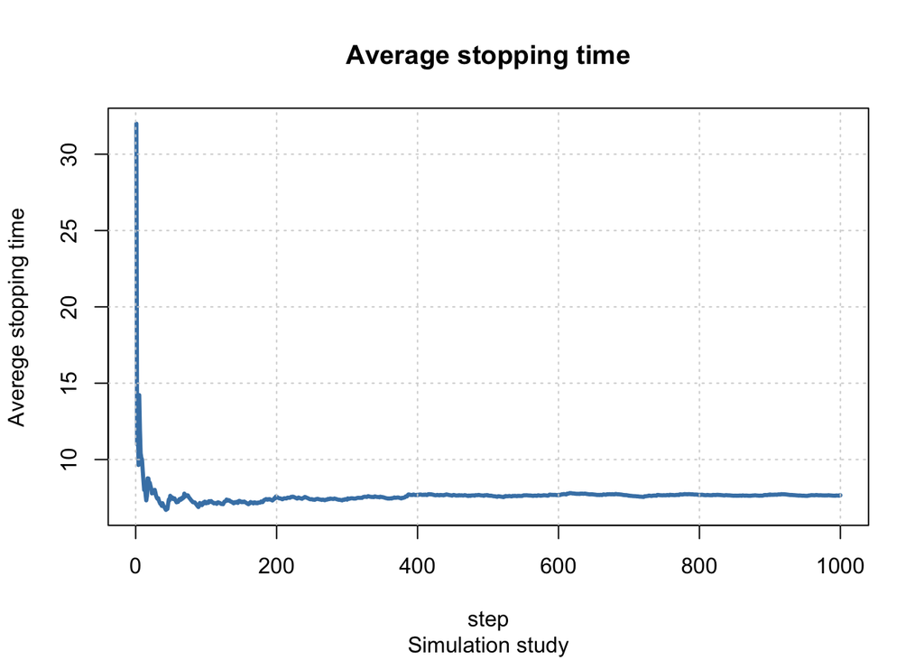

```r
{plot(ave_vec , main = "Average stopping time",
     xlab = "step", ylab = "Averege stopping time",
     sub = "Simulation study", col = "steelblue" , type = "l" , lwd =3)
grid()}
```

## Computational Analysis:

In this section, we would quantitatively check how the simulation size impacts the approximation, to show that, we are going to compute the distances between the true distribution and the estimated distribution. For these analysis, we have used the geometric distribution, since returns the same result but computationally faster.

```r
M <- 100   #How many errors we want to compute
diff <- matrix(NA , nrow =  length(Sim) , ncol = M )
for (j in 1:M){
  i <- 1
  for (s in Sim){
    stop_simulations <-  rgeom(n = s, prob = runif(n = s))   # run the simulation
    p_hat <- proportions(table(stop_simulations))

    diff[i,j] <- sum(pT(t_seq) - p_hat[t_seq], na.rm = T)
    i <- i + 1
}
}
```

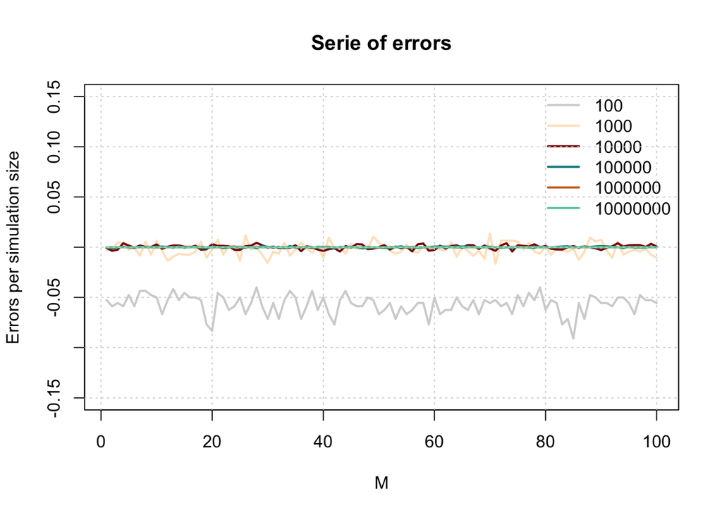

```r
error_matrix <- readRDS("simulation_data/error_matrix.rds")
colors <- c("lightgray" , "bisque" , "darkred" , "cyan4" , "Chocolate", "Medium Aquamarine")

plot(error_matrix[1,] , ylim = c(-0.15,0.15), type = "l" ,
     main = "Serie of errors", col = colors[1], lwd = 2,
     xlab = "M" , ylab = "Errors per simulation size")
for (i in 2:6){
  points(error_matrix[i,] , col = colors[i] , type = "l", lwd = 2)
}
options(scipen=999)
legend("topright", legend = Sim , col = colors , lwd = 2 , lty = 1  , bty = "n" )
grid()
```

The results shown an obvious reduction of the errors over M , the greatest difference can be seen from the passage from M = 100 to M = 1000.

## Statistical Analysis

In this section, we are supposed to be a Casino that wants to introduce this experiment in the available games. The player has to pay an amount of C euros to start this game and he wins as many euros as the waiting time.

The question we are interested to answer is: What is the “fair” amount to play this game?

To answer the question, we need to compute the expected value of this random variable. The fair amount you pay to enter the game is the expected value of the random variable.

The mathematical result provides a solution you can afford to pay any amount of C euros to play because on average you expect to win infinite.

Repeating this experiment many times, it will have to happen (with very low probability) to win a lot, enough for paying all the expenses incurred before.

From the statistical point of view, no difficulties is reached from the the situation illustrated in the game. In other words, it is perfectly coherent to accept the opportunity of an infinite win, such as to balance any amount paid in the (infinite) times the win is insignificant.

### Conclusion:

Ultimately, the decision to play or not to play this game must depend on each individual’s risk, itself dependent on many parameters, such as initial earnings or the amount you are willing to lose.

If the earnings here are “on average” infinite, you must also have infinite budgets and play an infinite number of times to be eligible for certain earnings.

No casinos would introduce this game, having the risk of infinite loss.

### Comments and further analysis:

A possible solution is to force the game to finish with a maximum win of L after the L-th trials.

Considering the fact of the greatest revenue fixed to L = 8 in the simulation study it results that a “fair” amount to pay is :

```r
L = 8    # max amount it can be won
stop_simulation_copy <- stop_time
stop_simulation_copy[stop_simulation_copy>7] <- L  # set all the observation greater than 7 to L
print(mean(stop_simulation_copy))
```

```
## [1] 2.7631
```

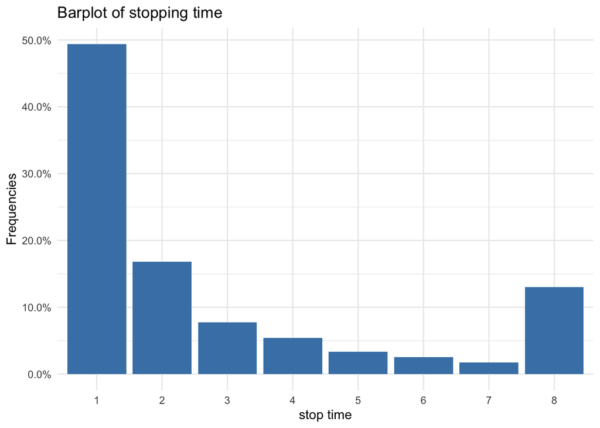

```r
tab = proportions(table(stop_simulation_copy))
library(ggplot2)
# Create Data
data=data.frame(tab)
ggplot(data, aes(x=stop_simulation_copy, y=Freq,fill=stop_simulation_copy))+
  geom_bar(stat="identity") +
  theme_minimal() +
  geom_bar(stat="identity", fill="steelblue")+
  xlab("stop time") + ylab("Frequencies") +  guides(fill="none") +
  ggtitle("Barplot of stopping time" ) +
  scale_y_continuous(labels=scales::percent)
```

Remark: 50% of the time the stopping time is equal to 1 corresponding to the payoff of the player.

The percentage of the time when the game is stopped is

```r
print(data$Freq[data$stop_simulation_copy == 8])
```

```
## [1] 0.1304
```

## Exercise 2 Differential Privacy

### 2.1

In this section, we focus on the univariate case with dimensionality $d = 1$ and we set up a simulation in order to compute the MISE: Mean Integrated Squared Error between the true model $p_{X}(·) ~ Beta(\alpha =10 ,\beta = 10)$ and the two approximation $\hat{p}_{n,m}(·)$ and $\hat{q}_{\epsilon,m}(·)$ where:

$$\hat{p}_{n,m}(·) = \sum_{j=1}^{m}
\frac{\hat{p}_{j}}{h^{d}} \mathbb{1}( x \in B_{j}) \hspace{0.3cm} with
\hspace{0.3cm} \hat{p}_{j} = \frac{\hat{n}_{j}}{n}$$

$$\hat{q}_{\epsilon,m}(·) = \sum_{j=1}^{m}
\frac{\hat{q}_{j}}{h^{d}} \mathbb{1}( x \in B_{j}) \hspace{0.3cm} with
\hspace{0.3cm} \hat{q}_{j} = \frac{\tilde{D_{j}}}{\sum_{s=1}^{m}
\tilde{D_{s}}} \hspace{0.3cm} where \hspace{0.3cm} \tilde{D_{j}} =
max\{0, D_{j}\} \hspace{0.3cm} and \hspace{0.3cm} D_{j} = \hat{n}_{j} +
\nu_{j}$$

```r
rm(list=ls())       #Clear output
library(VGAM)       # Library for the Laplacian Function
set.seed(13112221)  # For reproducibility
```

We compute the step function for both $\hat{p}$ and $\hat{q}$.

```r
# Step functions for p_hat
p_hat_func <- function(x , bins , p_hat){
  interval <- cut(x, bins, include.lowest = T)
  return(p_hat[interval])
}

# Step Function for q_hat
q_hat_func <- function(x, bins, q_hat){
  interval <- cut(x, bins, include.lowest = T)
  return(q_hat[interval])
}
```

Here we wrote the simulation function we are going to run. Inside we used the condition to define if the actual distribution is a $Beta$ or a Mixture of $Beta$ (Defined below) useful for the task 2.2. This function returns:

- MISE($p_{X} , \hat{p}_{n,m}$)
- MISE($p_{X} , \hat{q}_{\epsilon,m}$)
- MISE($\hat{p}_{n,m} , \hat{q}_{\epsilon,m}$)

```r
#####  Simulation Function #######
simulation_function <-function(m , sim_size = 100, n=100, h = 1/m , eps = .1, func='beta') #Define the parameters for the function
    {
  # Check the actual  distribution
  if(func == 'beta'){
    distr = function(x) dbeta(x,shape1 = 10, shape2 = 10)
    sample_distr = function(n) rbeta(n, 10, 10)}
  else if(func == 'mixture'){
    distr = dmixture
    sample_distr = function(n) rmixture(n)}
  else{stop("The 'func' input is wrong. Choose between 'beta' or 'mixture'!")}   # We only compute for Beta and Mixture

  matr_integral <- matrix(NA , nrow = sim_size  , ncol = 3)     # Pre allocate teh values

  for(rep in 1:sim_size){   # Loop over the simulation size

    X <- sample_distr(n)    # Generate the random sample from the beta distribution

    bins <- seq(0, 1, h)    # Set the bins

    intervals <- cut(X, bins, include.lowest = T)  # Rename units with the bins they belong


    pj_hat <- table(intervals) / n                 # Find the frequencies of units inside each bins


    p_hat <- as.vector(pj_hat / h)                 # Compute high of each bin dividing the frequencies for the width of the bin

    nu <- rlaplace(m, 0, 2/eps)                    # Generate m values from a Laplacian distribution: one for each bin


    Dj <- table(intervals) + nu                    # Add the noise nu to every absolute frequencies of each bin

    Dj[Dj < 0] = 0                                 # Set all the negatives values to 0



    # Find qj_hat dividing max(0, Dj) for the sum of Dj
    # Check also if sum of Dj is equal to 0 to avoid NaN in R
    # It would means that all the values are zero
    if (sum(Dj) != 0){
      qj_hat <- Dj / sum(Dj)} else {qj_hat <- rep(0, length(Dj))}


    q_hat <- qj_hat / h                             # Compute the high of the histogram dividing by the width of the columns

    # Compute the integral
    p <- integrate(function(x) ( distr(x) - p_hat_func(x,bins = bins , p_hat = p_hat))^2 , lower = 0 , upper = 1, subdivisions = 1200)$value

    q <- integrate(function(x) (( distr(x) - q_hat_func(x,bins = bins , q_hat = q_hat ))^2), lower = 0 , upper = 1, subdivisions = 1200)$value
    pq <- integrate(function(x) (( p_hat_func(x,bins = bins , p_hat = p_hat ) - q_hat_func(x,bins = bins , q_hat = q_hat ))^2), lower = 0 , upper = 1, subdivisions = 1200)$value

    matr_integral[rep,1] <- p         # Allocate the result
    matr_integral[rep,2] <- q         # Allocate the result
    matr_integral[rep,3] <- pq        # Allocate the result


  }
  mise_p <- mean(matr_integral[,1])   #Save the results
  mise_q <- mean(matr_integral[,2])   #Save the results
  mise_pq <- mean(matr_integral[,3])
  return(c(mise_p , mise_q, mise_pq))
}
```

We run the simulation with the parameters setted to :

- $\epsilon = \{0.1,0.001\}$
- $n = \{100,1000\}$
- $m = seq(from = 5 , to =50 , by =1)$
- $M = 100$

plots are shown below:

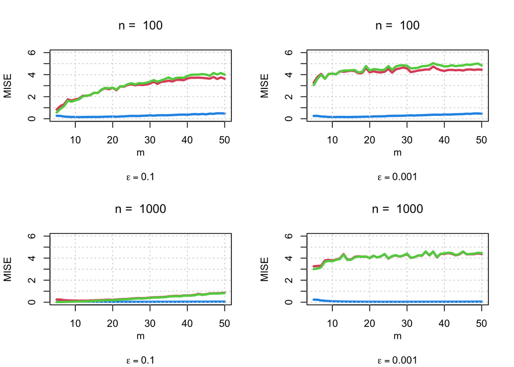

```r
par(mfrow=c(2,2), font.main=1)

colors <- c("#2297E6", "#DF536B", '#61D04F')
y_lim <- 6
eps <- c(.1, .001, .1, .001)
enne <- c(100, 100, 1000, 1000)
### Beta Plot
data <- c('beta_n100_eps_01', 'beta_n100_eps_0001', 'beta_n1000_eps_01', 'beta_n1000_eps_0001')

for(i in 1:4){
  load(paste0('simulation_data/',data[i],'.RData'))
  d <- eval(parse(text = data[i]))
  p_hat <- d$p_hat
  q_hat <- d$q_hat
  pq <- d$pq

  plot(5:(length(p_hat)+4), p_hat, ylab='MISE', xlab='', sub = bquote(epsilon == .(eps[i])), type='l', lwd=3, col=colors[1], ylim=c(0,y_lim), main = paste('n = ', enne[i]))
  grid()
  mtext(text = 'm',side = 1, line = 2, cex=.8)
  points(5:(length(q_hat)+4), q_hat, type='l', lwd=3, col=colors[2])
  points(5:(length(pq)+4), pq, type='l', lwd=3, col=colors[3])
}
```

### 2.2

In this task we repeat the simulation replacing the $Beta(\alpha = 10 , \beta = 10)$ with a mixture of two Beta’s

$$p_{X}(x) = \pi \cdot dbeta(x|
\alpha_{1}, \beta_{1}) + (1 - \pi) \cdot
dbeta(x|\alpha_{2},\beta_{2})$$

where we have setted the parameter as following :

- $\pi = 0.6$
- $\alpha_{1} = 2$
- $\beta_{1} = 15$
- $\alpha_{2} = 12$
- $\beta_{2} = 6$

We define two function to determinate the density distribution of the mixture model and in order to generate a sample of size n from the model.

```r
##### Mixture distribution of Beta ######
dmixture <- function(x, shape_1 = 2 , shape_2 = 15 , shape_3 = 12 , shape_4 = 6 , pi = 0.6 ){
  f <- pi * dbeta(x, shape1 = shape_1 , shape2 = shape_2) + (1 - pi) * dbeta(x, shape1 = shape_3 , shape2 = shape_4)
  return(f)
}

##### Random sample from Mixture Beta  #####
rmixture <- function(n, shape_1 = 2 , shape_2 = 15 , shape_3 = 12 , shape_4 = 6 , pi = 0.6 ){
  sam <- c()
  u <- runif(n)
  for (x in u){
    if (x < pi) sam <-c(sam, rbeta(1, shape1 = shape_1 , shape2 = shape_2))
    else sam <- c(sam , rbeta(1, shape1 = shape_3 , shape2 = shape_4) )
  }
  return(sam)
}
```

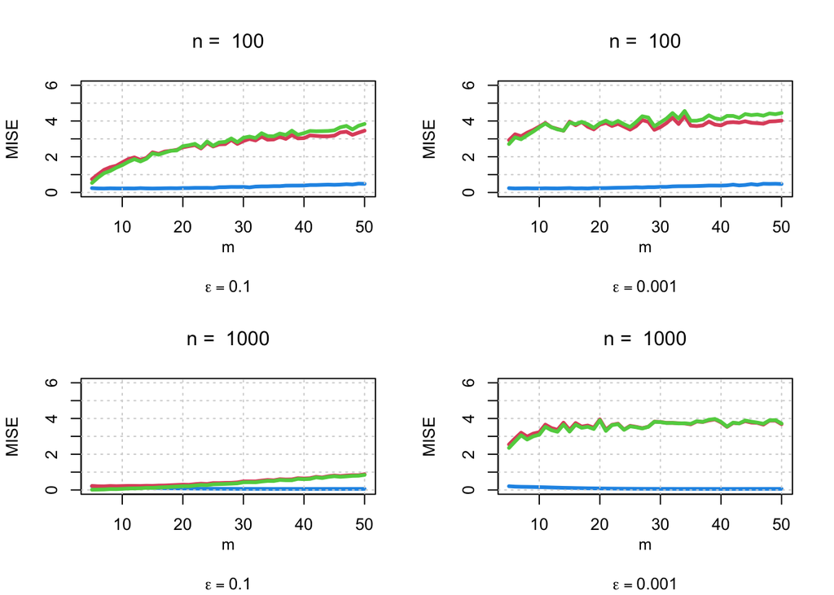

```r
par(mfrow=c(2,2), font.main=1)
data <- c('mixture_n100_eps_01', 'mixture_n100_eps_0001', 'mixture_n1000_eps_01', 'mixture_n1000_eps_0001')

for(i in 1:4){
  load(paste0('simulation_data/',data[i],'.RData'))
  d <- eval(parse(text = data[i]))
  p_hat <- d$p_hat
  q_hat <- d$q_hat
  pq <- d$pq

  plot(5:(length(p_hat)+4), p_hat, ylab='MISE', xlab='', sub = bquote(epsilon == .(eps[i])), type='l', lwd=3, col=colors[1], ylim=c(0,y_lim), main = paste('n = ', enne[i]))
  grid()
  mtext(text = 'm',side = 1, line = 2, cex=.8)
  points(5:(length(q_hat)+4), q_hat, type='l', lwd=3, col=colors[2])
  points(5:(length(pq)+4), pq, type='l', lwd=3, col=colors[3])
}
```

### Comments on Beta:

The MISE($p_{X} , \hat{p}_{n,m}$) results close to 0 since we are evaluating the differences between the true distribution and an estimated distribution built from a sample of the true model. Increasing the value of n from n = 100 to n = 1000 we can see that the MISE is a the decreasing function of m, because by adding more bins the histogram will be an adequate representation of the true distribution.

In the case of n = 100 the blue line increase with large m, because we have only 100 data to put inside many bins and may happen that a lot of bins are empty or with few units inside: this implied a more significant distance from the two models.

The MISE($p_{X} , \hat{q}_{\epsilon,m}$) is closer to the MISE($p_{X} , \hat{p}_{n,m}$) when we evaluated it with a bigger $\epsilon$. In the case of n = 100 the differences is not remarkable but increasing n to 1000 the two MISE are obviously more similar. It means that when $\epsilon$ is too big , results a not efficient privatization, in the other hand, when $\epsilon$ too small we have a good privatization to the detriment of huge difference between the two distribution.

The MISE($\hat{p}_{n,m} , \hat{q}_{\epsilon,m}$) is a measure of the distance between the histogram of $\hat{p}_{n,m}$ and $\hat{q}_{\epsilon ,m }$. Results are influenced by the fact that the $\hat{p}_{n,m}(·)$ model, being a good approximation of the true model, results a MISE almost always close to 0 and then the MISE$( \hat{q}_{\epsilon,m}, \hat{p}_{n,m})$ $\approx$ MISE( $\hat{q}_{\epsilon,m}, \hat{p}_{n,m}$).

### Comments on Mixture:

When the actual histogram is sparse, the Laplace noise introduce mass into some bins where it should not be, this impact a lot on the similarity of the two distribution deleting the clustering structure that the model (i.e. Mixture we used ) has.

### 2.3

The goal of this task is to privatize a data set. We collect data by having university students fill out a form about the frequency of their monthly workouts during 2022/2023. We collect 100 observations in order to study the distribution and statistics of this feature that can be useful to understand physical health. Work-out are often uncomfortable topics and since that we will share a privatized data set built according to the perturbed histogram approach.

We set $k = 100$ in order to reppresent all the population.

We define a function that privatize a data-set as the following:

```r
##### Load the dataset #####
library(readr)
fitness <- read_csv("fitness.csv")   # Read the dataset
n <- nrow(fitness)
colnames(fitness) <- c("index" , "Frequences_per_mounth")   # Rename the column
fitness$index <- seq(from = 1 , to = n , by = 1)


# Normalize the data
maximum <- max(fitness$Frequences_per_mounth)
minimun <-  min(fitness$Frequences_per_mounth)

fitness$norm <-  round(( fitness$Frequences_per_mounth -  minimun ) / (maximum - minimun) , 2)


##### Build the privatized function #####
privatized_engine <- function(
    data = fitness$norm, m = 20 , h = 1 / m , eps = 0.1  )
  {
  n = length(data)        # Number of the observations
  bins <-  seq(0,1,h)     # Number of bins
  intervals <- cut( data, bins, include.lowest = T)
  pj_hat <- table(intervals) / n
  p_hat <- as.vector(pj_hat / h)
  nu <- rlaplace(m, 0, 2/eps)  # Perturbeb data
  Dj <- table(intervals) + nu
  Dj[Dj < 0] = 0
  qj_hat = Dj
  if (sum(qj_hat) != 0){qj_hat <- qj_hat / sum(qj_hat)} else {qj_hat <- rep(0, length(qj_hat))}


  q_absfre <- round(qj_hat * n , 0 )


  Z <- c()         #Build the new dataset
  i <- 0
  for ( x in q_absfre ){
    i <- i + 1
    Z <- c(Z, runif(x, bins[i],bins[i+1]))
  }

  private_dat <- data.frame(Z)

  private_dat$index <- seq(from = 1 , to = length(private_dat) , 1)

  colnames(private_dat) <- c("privatized_times_norm" , "index")
  private_dat$privatized_times <- (private_dat$privatized_times_norm) * maximum
  return(private_dat)

}


dataset <- privatized_engine(data = fitness$norm)
summary(dataset$privatized_times)
```

```
##     Min.  1st Qu.   Median     Mean  3rd Qu.     Max.
##  0.08911 10.66085 14.55778 14.49447 20.38142 29.89598
```

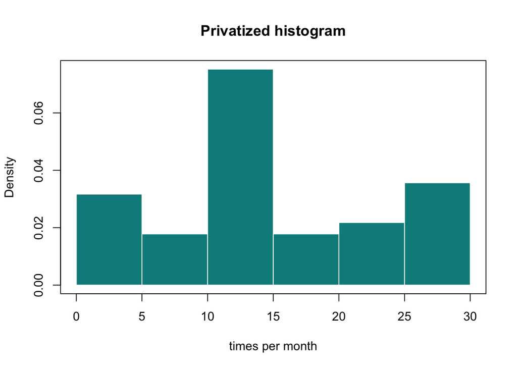

```r
hist(dataset$privatized_times, main = "Privatized histogram" , xlab = 'times per month' , freq = F , col = "cyan4" , border = "white")
box()
```